# Indexação avançada de vetores e dataframes

Daniel Maurenza de Oliveira

https://github.com/dmaurenza/Curso-Intermediario-R

Nesta aula vamos aprender a utilizar a ferramenta “Project”, que auxilia a organização dos arquivos utilizados no R durante o desenvolvimento de um projeto. Também iremos avançar nos conceito de Indexação. Veremos como indexar elementos de um vetor e de um dataframe de forma condicional. Também veremos como a fazer substituição de valores usando indexação através da função “ifelse”

# Elementos da Aula

1. Ferramenta “Project”
2. Indexação lógica
3. Operações condicionais em vetores
4. Operações condicionais em dataframes
5. Operação condicionante “ifelse”

## Ferramenta “Project”

A ferramenta “Project” nos garante que todos os scripts gerados sejam organizados na mesma pasta-master. Além de termos os arquivos mais organizados, isto facilita o compartilhamento dos scripts e dados com outras pessoas, evitando erros comuns relacionados aos caminhos dos arquivos.

Para sabermos onde nossos arquivos estão sendo salvos, usamos a função “getwd(), abreviação de Get Working Directory”

```r
getwd()
```

```
## [1] "D:/Unifesp/Curso-Intermediario-R"
```

a função “setwd()”, abreviação de Set Working Directory, define a pasta-master. Ou seja, todas os arquivos se referem à essa pasta

```r
setwd("D:/")
getwd()
```

Usando a ferramenta “Project” (File > New Project > New Directory > New Project), nós definimos o nome do projeto e o caminho onde será armazenado no nosso computador (diretório). A partir de agora, basta incluirmos organizadamente todos os arquivos do nosso projeto dentro do diretório.

## Indexação lógica

Apesar de reter ou eliminar posições específicas de um objeto ser uma operação útil, na maior parte das vezes queremos realizar esta tarefa para conjuntos dos dados que cumpram certos requerimentos (por exemplo, reter apenas as observações de uma determinada categoria).

Uma forma de fazer isto é através de operações lógicas. Para executar operações lógicas, utilizamos alguns caracteres especiais.

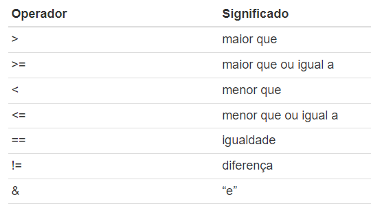

O número 4 é maior do que o 5?

```r
4 > 5
```

```
## [1] FALSE
```

O número 4 é menor do que o 5?

```r
4 < 5
```

```
## [1] TRUE
```

O número 4 é igual ao 5?

```r
4 == 5
```

```
## [1] FALSE
```

O número 4 é diferente do 5?

```r
4 != 5
```

```
## [1] TRUE
```

Uma palavra é igual a outra?

```r
"Ola" == "Tchau"
```

```
## [1] FALSE
```

```r
"Ola" == "Ola"
```

```
## [1] TRUE
```

Uma palavra é diferente da outra?

```r
"Ola" != "Tchau"
```

```
## [1] TRUE
```

```r
"Ola" != "Ola"
```

```
## [1] FALSE
```

## Operações condicionais em vetores

Primeiro, vamos criar uma amostra de valores com distribuição normal

```r
vetor1 <- seq(from = 23, to = 34,
              length.out = 100)

vetor1
```

```
##   [1] 23.00000 23.11111 23.22222 23.33333 23.44444 23.55556 23.66667 23.77778
##   [9] 23.88889 24.00000 24.11111 24.22222 24.33333 24.44444 24.55556 24.66667
##  [17] 24.77778 24.88889 25.00000 25.11111 25.22222 25.33333 25.44444 25.55556
##  [25] 25.66667 25.77778 25.88889 26.00000 26.11111 26.22222 26.33333 26.44444
##  [33] 26.55556 26.66667 26.77778 26.88889 27.00000 27.11111 27.22222 27.33333
##  [41] 27.44444 27.55556 27.66667 27.77778 27.88889 28.00000 28.11111 28.22222
##  [49] 28.33333 28.44444 28.55556 28.66667 28.77778 28.88889 29.00000 29.11111
##  [57] 29.22222 29.33333 29.44444 29.55556 29.66667 29.77778 29.88889 30.00000
##  [65] 30.11111 30.22222 30.33333 30.44444 30.55556 30.66667 30.77778 30.88889
##  [73] 31.00000 31.11111 31.22222 31.33333 31.44444 31.55556 31.66667 31.77778
##  [81] 31.88889 32.00000 32.11111 32.22222 32.33333 32.44444 32.55556 32.66667
##  [89] 32.77778 32.88889 33.00000 33.11111 33.22222 33.33333 33.44444 33.55556
##  [97] 33.66667 33.77778 33.88889 34.00000
```

```r
media <- mean(x = vetor1)

desvio <- sd(x = vetor1)

amostra1 <- rnorm(n = 20, mean = media,
                  sd = desvio)
amostra1
```

```
##  [1] 25.50455 25.08022 29.86462 31.98872 25.33275 29.15513 25.97890 25.66346
##  [9] 28.52605 27.96912 29.45958 28.55867 30.26090 26.57371 24.98371 22.60381
## [17] 28.97607 26.85147 26.56065 29.16621
```

```r
length(amostra1)
```

```
## [1] 20
```

Agora vamos fazer algumas operações lógicas.

```r
amostra1 > 25
```

```
##  [1]  TRUE  TRUE  TRUE  TRUE  TRUE  TRUE  TRUE  TRUE  TRUE  TRUE  TRUE  TRUE
## [13]  TRUE  TRUE FALSE FALSE  TRUE  TRUE  TRUE  TRUE
```

Quais elementos do vetor amostra são menores ou iguais a 32?

```r
amostra1 <= 32
```

```
##  [1] TRUE TRUE TRUE TRUE TRUE TRUE TRUE TRUE TRUE TRUE TRUE TRUE TRUE TRUE TRUE
## [16] TRUE TRUE TRUE TRUE TRUE
```

Podemos usar a mesma lógica para retermos caracteres que assumam determinados valores.

Para exemplificar, vamos criar uma sequência de letras de “A” a “J” para representar quadrantes de amostragem

```r
quadrats1 <- rep(LETTERS[1:10], each = 2)

quadrats1
```

```
##  [1] "A" "A" "B" "B" "C" "C" "D" "D" "E" "E" "F" "F" "G" "G" "H" "H" "I" "I" "J"
## [20] "J"
```

Quais letras são iguais a “A”

```r
quadrats1 == "A"
```

```
##  [1]  TRUE  TRUE FALSE FALSE FALSE FALSE FALSE FALSE FALSE FALSE FALSE FALSE
## [13] FALSE FALSE FALSE FALSE FALSE FALSE FALSE FALSE
```

Quais letras não são iguais a “A”

```r
quadrats1 != "A"
```

```
##  [1] FALSE FALSE  TRUE  TRUE  TRUE  TRUE  TRUE  TRUE  TRUE  TRUE  TRUE  TRUE
## [13]  TRUE  TRUE  TRUE  TRUE  TRUE  TRUE  TRUE  TRUE
```

Vamos fazer alguns exercícios juntos

```r
# 1.
amostra1 < 31
```

```
##  [1]  TRUE  TRUE  TRUE FALSE  TRUE  TRUE  TRUE  TRUE  TRUE  TRUE  TRUE  TRUE
## [13]  TRUE  TRUE  TRUE  TRUE  TRUE  TRUE  TRUE  TRUE
```

```r
amostra1 > 29
```

```
##  [1] FALSE FALSE  TRUE  TRUE FALSE  TRUE FALSE FALSE FALSE FALSE  TRUE FALSE
## [13]  TRUE FALSE FALSE FALSE FALSE FALSE FALSE  TRUE
```

```r
amostra1 < 31 & amostra1 > 29
```

```
##  [1] FALSE FALSE  TRUE FALSE FALSE  TRUE FALSE FALSE FALSE FALSE  TRUE FALSE
## [13]  TRUE FALSE FALSE FALSE FALSE FALSE FALSE  TRUE
```

```r
# 2.
amostra1 >=25
```

```
##  [1]  TRUE  TRUE  TRUE  TRUE  TRUE  TRUE  TRUE  TRUE  TRUE  TRUE  TRUE  TRUE
## [13]  TRUE  TRUE FALSE FALSE  TRUE  TRUE  TRUE  TRUE
```

```r
amostra1 < 29
```

```
##  [1]  TRUE  TRUE FALSE FALSE  TRUE FALSE  TRUE  TRUE  TRUE  TRUE FALSE  TRUE
## [13] FALSE  TRUE  TRUE  TRUE  TRUE  TRUE  TRUE FALSE
```

```r
amostra1 >=25 | amostra1 < 29
```

```
##  [1] TRUE TRUE TRUE TRUE TRUE TRUE TRUE TRUE TRUE TRUE TRUE TRUE TRUE TRUE TRUE
## [16] TRUE TRUE TRUE TRUE TRUE
```

É importante notar que ao fazermos estes testes, o resultado retornado é um vetor

```r
maior28 <- amostra1 > 28

is.vector(maior28)
```

```
## [1] TRUE
```

Portanto, podemos usar estes testes lógicos para indexar vetores também

```r
amostra1[maior28]
```

```
## [1] 29.86462 31.98872 29.15513 28.52605 29.45958 28.55867 30.26090 28.97607
## [9] 29.16621
```

```r
# outra forma de obter o mesmo resultado
amostra1[amostra1 > 28]
```

```
## [1] 29.86462 31.98872 29.15513 28.52605 29.45958 28.55867 30.26090 28.97607
## [9] 29.16621
```

Também podemos usar um vetor para indexar um outro vetor, desde que eles tenham o mesmo tamanho.

Quais as categorias de letras são iguais a “B”?

```r
letraB <- quadrats1 == "B"

letraB
```

```
##  [1] FALSE FALSE  TRUE  TRUE FALSE FALSE FALSE FALSE FALSE FALSE FALSE FALSE
## [13] FALSE FALSE FALSE FALSE FALSE FALSE FALSE FALSE
```

Quais os elementos do vetor1 pertencem à categoria letra “B”?

```r
amostra1[letraB]
```

```
## [1] 29.86462 31.98872
```

##### Exercícios

1. Crie um vetor de número de 1 a 100 e guarde este vetor em um objeto.
2. Crie um segundo vetor com duas categorias: “impar” e “par” (nesta ordem), e guarde em um objeto.
3. Faça com que os valores “impar” e “par” sejam repetidos 50 vezes, de forma intercalada (“impar”, “par”, “impar”, “par”, …); guarde isso em um objeto.
4. Indexe o vetor criado no passo “1” de forma que somente os números em posição par sejam apresentados.

## Operações condicionais em dataframes

Este último exercício nos mostra que podemos usar condições relacionadas a um vetor para indexar valores em um outro vetor. Isto é um passo importante para entendermos as operações condicionais em um dataframe.

Muito frequentemente, ao trabalharmos com a indexação de um dataframe, o nosso objetivo é selecionar, ou excluir, as linhas que satisfaçam uma ou mais condições.

Estas linhas correspondem a um conjunto de observações que descrevem um conjunto particular de dados. Para entender melhor as operações condicionais em um dataframe, vamos usar nossa tabela de Alunos

```r
library(tidyverse)
alunos <- read_csv("dados/alunos_alterado.csv")
```

Você deve se lembrar que uma das formas de indexarmos um dataframe é como em um jogo de batalha naval: dados[linhas, colunas].

```r
alunos[c(1:3), c(2:3)]
```

```
## # A tibble: 3 × 2
##   idade sexo
##   <dbl> <chr>
## 1    39 M
## 2    20 F
## 3    40 M
```

Como vimos ainda pouco, para indexarmos dataframes fornecemos um vetor para cada lado da vírgula, determinando assim as posições a serem retidas. Podemos usar isso em nosso favor para fazermos operações lógicas em dataframes

Mas primeiro, vamos lembrar como indexar uma coluna de um dataframe através do operador $.

```r
# retorna um vetor com as classes de sexo
alunos$sexo
```

```
## [1] "M" "F" "M" "F"
```

```r
# retorna um vetor com os valores de idade
alunos$idade
```

```
## [1] 39 20 40 25
```

```r
# retorna um vetor com os números do tamanho dos pé
alunos$pe
```

```
## [1] 40 35 37 33
```

Note que, em todos os casos, ao usarmos o operador $ estamos indexando uma coluna e tendo como resultado um vetor

```r
masculino <- alunos$sexo == "M"
masculino
```

```
## [1]  TRUE FALSE  TRUE FALSE
```

```r
is.vector(masculino)
```

```
## [1] TRUE
```

Assim, se quisermos indexar o vetor “masculino” dentro do dataframe alunos…

```r
alunos$sexo[masculino]
```

```
## [1] "M" "M"
```

Acabamos de ver que podemos usar uma operação de lógica em um vetor para filtrar outro vetor. Como podemos aplicar isto a um dataframe então?

Lembre-se que um dataframe “conhece” os vetores que o compõe! Se quiséssemos indexar apenas as linhas que correspondem ao sexo masculino

```r
alunos[alunos$sexo == "M",]
```

```
## # A tibble: 2 × 10
##   nome              idade sexo  altura  peso trans…¹ semes…²    pe   mao inici…³
##   <chr>             <dbl> <chr>  <dbl> <dbl> <chr>     <dbl> <dbl> <dbl> <lgl>
## 1 Daniel Maurenza …    39 M        1.7    72 Publico       5    40    22 TRUE
## 2 Joao                 40 M        1.8    90 Privado       5    37    20 FALSE
## # … with abbreviated variable names ¹transporte, ²semestre, ³iniciante
```

Podemos ainda determinar quais colunas também queremos reter

```r
alunos[alunos$sexo == "M", c(1:5)]
```

```
## # A tibble: 2 × 5
##   nome                        idade sexo  altura  peso
##   <chr>                       <dbl> <chr>  <dbl> <dbl>
## 1 Daniel Maurenza de Oliveira    39 M        1.7    72
## 2 Joao                           40 M        1.8    90
```

Podemos extender o uso da indexação para mais de uma condição.

Reter todas as observações que correspondam aos alunos do semestre 3 OU 4

```r
alunos[alunos$semestre == 3 | alunos$semestre == 4, ]
```

```
## # A tibble: 1 × 10
##   nome  idade sexo  altura  peso transporte semestre    pe   mao iniciante
##   <chr> <dbl> <chr>  <dbl> <dbl> <chr>         <dbl> <dbl> <dbl> <lgl>
## 1 Maria    20 F       1.58    49 Publico           4    35    20 FALSE
```

```r
alunos[alunos$semestre == 3:4, ]
```

```
## # A tibble: 1 × 10
##   nome  idade sexo  altura  peso transporte semestre    pe   mao iniciante
##   <chr> <dbl> <chr>  <dbl> <dbl> <chr>         <dbl> <dbl> <dbl> <lgl>
## 1 Maria    20 F       1.58    49 Publico           4    35    20 FALSE
```

Reter todas as observações que correspondam aos alunos acima do semestre 3 OU cujos alunos tenham mais que 25 anos de idade

```r
alunos[alunos$semestre > 3 | alunos$idade > 25, ]
```

```
## # A tibble: 3 × 10
##   nome              idade sexo  altura  peso trans…¹ semes…²    pe   mao inici…³
##   <chr>             <dbl> <chr>  <dbl> <dbl> <chr>     <dbl> <dbl> <dbl> <lgl>
## 1 Daniel Maurenza …    39 M       1.7     72 Publico       5    40    22 TRUE
## 2 Maria                20 F       1.58    49 Publico       4    35    20 FALSE
## 3 Joao                 40 M       1.8     90 Privado       5    37    20 FALSE
## # … with abbreviated variable names ¹transporte, ²semestre, ³iniciante
```

Reter todas as observações que correspondam aos alunos acima do semestre 3 E cujos alunos tenham mais que 25 anos de idade

```r
alunos[alunos$semestre > 3 & alunos$idade > 25, ]
```

```
## # A tibble: 2 × 10
##   nome              idade sexo  altura  peso trans…¹ semes…²    pe   mao inici…³
##   <chr>             <dbl> <chr>  <dbl> <dbl> <chr>     <dbl> <dbl> <dbl> <lgl>
## 1 Daniel Maurenza …    39 M        1.7    72 Publico       5    40    22 TRUE
## 2 Joao                 40 M        1.8    90 Privado       5    37    20 FALSE
## # … with abbreviated variable names ¹transporte, ²semestre, ³iniciante
```

Reter todas as observações que correspondam aos alunos acima do semestre 3 E abaixo do semestre 8

```r
alunos[alunos$semestre > 3 & alunos$semestre < 8, ]
```

```
## # A tibble: 3 × 10
##   nome              idade sexo  altura  peso trans…¹ semes…²    pe   mao inici…³
##   <chr>             <dbl> <chr>  <dbl> <dbl> <chr>     <dbl> <dbl> <dbl> <lgl>
## 1 Daniel Maurenza …    39 M       1.7     72 Publico       5    40    22 TRUE
## 2 Maria                20 F       1.58    49 Publico       4    35    20 FALSE
## 3 Joao                 40 M       1.8     90 Privado       5    37    20 FALSE
## # … with abbreviated variable names ¹transporte, ²semestre, ³iniciante
```

Reter todas as observações que correspondam aos alunos acima do semestre 3 E cujos alunos tenham mais que 25 anos de idade E que sejam homens.

```r
alunos[alunos$semestre > 3 & alunos$idade > 25 & alunos$sexo == "M", ]
```

```
## # A tibble: 2 × 10
##   nome              idade sexo  altura  peso trans…¹ semes…²    pe   mao inici…³
##   <chr>             <dbl> <chr>  <dbl> <dbl> <chr>     <dbl> <dbl> <dbl> <lgl>
## 1 Daniel Maurenza …    39 M        1.7    72 Publico       5    40    22 TRUE
## 2 Joao                 40 M        1.8    90 Privado       5    37    20 FALSE
## # … with abbreviated variable names ¹transporte, ²semestre, ³iniciante
```

### Exercícios

5. Indexe, ou selecione, todas as linhas de “alunos” cujo valor da coluna peso seja maior do que 65 (inclusive);
6. Selecione todas as linhas de “alunos” que correspondam às mulheres da turma, mas removendo as colunas “semestre”, “pe”, “mao” e “iniciante”.
7. Retenha uma linha única que corresponde aos seus dados, contendo as informações sobre nome, idade, sexo e altura, mediante as seguintes regras:
- Não use a coluna nome (ex. alunos$nome == “Daniel Maurenza de Oliveira”).
- Utilize pelo menos 3 comandos distintos para selecionar a linha.
- O penúltimo comando deve selecionar mais do que uma linha.

## Operação condicionante “ifelse”

Por fim, vamos aprender a operação condicionante “ifelse”. ifelse usa um teste lógico para executar uma ação, que tem a seguinte lógica:

- Dado um teste lógico;
- Faça isto caso ele seja verdadeiro, ou;
- Faça isto caso ele seja falso.

```r
args(ifelse)
```

```
## function (test, yes, no)
## NULL
```

Primeiramente, vamos ver como ifelse funciona com “vetores”. A leitura do código fica mais fácil se inserirmos cada argumento em uma nova linha

```r
vetor1 <- 20:30

ifelse(test = vetor1 <= 23,
       yes = "baixo",
       no = "alto")
```

```
##  [1] "baixo" "baixo" "baixo" "baixo" "alto"  "alto"  "alto"  "alto"  "alto"
## [10] "alto"  "alto"
```

Veja como podemos usar esta função na nossa tabela Alunos

```r
mao <- alunos$mao

ifelse(test = mao >= 21,
       yes = "maozão",
       no = "maozinha")
```

```
## [1] "maozão"   "maozinha" "maozinha" "maozão"
```

Você pode encadear diversos testes e substituições lógicas, mas cuidado - isto tende a se tornar cada vez mais complexo!

```r
ifelse(test = mao >= 23,
       yes = "maozão",
       no = ifelse(test = mao < 23 & mao >= 21,
                   yes = "regular",
                   no = "maozinha"))
```

```
## [1] "regular"  "maozinha" "maozinha" "regular"
```

Agora, vamos ver como ifelse funciona com “dataframes.” A sequência lógica é a mesma, porém temos que indexar um dataframe.

```r
classe_mao <- ifelse(test = alunos$mao >= 21,
                     yes = "maozão",
                     no = "maozinha")
```

No dataframe, podemos criar uma nova coluna, ou substituir a coluna existente:

```r
alunos$mao_classe <- ifelse(test = alunos$mao >= 21,
                            yes = "maozão",
                            no = "maozinha")
alunos
```

```
## # A tibble: 4 × 11
##   nome      idade sexo  altura  peso trans…¹ semes…²    pe   mao inici…³ mao_c…⁴
##   <chr>     <dbl> <chr>  <dbl> <dbl> <chr>     <dbl> <dbl> <dbl> <lgl>   <chr>
## 1 Daniel M…    39 M       1.7     72 Publico       5    40    22 TRUE    maozão
## 2 Maria        20 F       1.58    49 Publico       4    35    20 FALSE   maozin…
## 3 Joao         40 M       1.8     90 Privado       5    37    20 FALSE   maozin…
## 4 Joana        25 F       1.75    65 Publico       1    33    21 TRUE    maozão
## # … with abbreviated variable names ¹transporte, ²semestre, ³iniciante,
## #   ⁴mao_classe
```

```r
alunos$mao <- ifelse(test = mao >= 23,
                     yes = "maozão",
                     no = ifelse(test = mao < 23 & mao >= 21,
                                 yes = "regular",
                                 no = "maozinha"))
alunos
```

```
## # A tibble: 4 × 11
##   nome      idade sexo  altura  peso trans…¹ semes…²    pe mao   inici…³ mao_c…⁴
##   <chr>     <dbl> <chr>  <dbl> <dbl> <chr>     <dbl> <dbl> <chr> <lgl>   <chr>
## 1 Daniel M…    39 M       1.7     72 Publico       5    40 regu… TRUE    maozão
## 2 Maria        20 F       1.58    49 Publico       4    35 maoz… FALSE   maozin…
## 3 Joao         40 M       1.8     90 Privado       5    37 maoz… FALSE   maozin…
## 4 Joana        25 F       1.75    65 Publico       1    33 regu… TRUE    maozão
## # … with abbreviated variable names ¹transporte, ²semestre, ³iniciante,
## #   ⁴mao_classe
```

## Exercícios

8. Usando a função “ifelse”, crie uma nova coluna representando a classe de altura. Classifique alunos menores que 1.6m como “baixo”, alunos iguais ou maiores que 1,6m e menores que 1,9m como “médio”, e alunos maiores ou iguais a 1,9m como “alto”.

# Para casa

Vamos usar uma tabela de dados que já existe no seu R: airquality. Primeiramente, explore o seu conteúdo e estrutura utlizando as funções help, str ou glimpse.

1. Retenha todas as colunas cujas linhas pertençam ao mês 8;
2. Retenha todas as linhas cuja temperatura seja maior que 70 E a concentração de ozônio maior do que 80;
3. Retenha todas as observações que tenham a velocidade do vento maior do que 10 E menor do que 15 OU cuja temperatura seja maior ou igual a 86;
4. Por fim, retenha todas as linhas cujo ozônio seja maior do 100, a radiação solar seja menor do que 230 e que a temperatura seja maior ou igual a 90.